# Simple and Multi Linear Regression Example

Machine Learning and Predictive Analytics

Author

B. Williams

Published

November 1, 2023

## Problem 1

This question involves the use of simple linear regression and multi-linear regression on the **Carseats** dataset.

### **1a. Use the lm() function to perform a simple linear regression with Sales as the response and Price as the predictor. Use the summary() function to print the results. Comment on the output: “Is there a relationship between Sales and Price? If so, is the relationship positive or negative? How strong is the relationship?”**

This code is straightforward. I install/load any packages required for this assignment, set my working directory using the setwd() function, and then load the data using the read.csv() function. Following these functions, I use the attach() function to attach the dataset to the R search path. In other words, this function allows me to call the variables by name instead of using “Carseats$VariableName.”

```r
# Setting Directory and loading libraries
setwd("c:/Users/brand/OneDrive/Desktop/BUAD 5122/M2")
library(performance)
library(see)
library(car)
library(ISLR)
#Q.A Loading data
Carseats <- read.csv("Carseats.csv")
attach(Carseats)
```

```r
#Simple Linear Regression
simple_lm <- lm(Sales ~ Price, Carseats)

#Print out summary
summary(simple_lm)
```

```
Call:
lm(formula = Sales ~ Price, data = Carseats)

Residuals:
    Min      1Q  Median      3Q     Max
-6.5224 -1.8442 -0.1459  1.6503  7.5108

Coefficients:
             Estimate Std. Error t value Pr(>|t|)
(Intercept) 13.641915   0.632812  21.558   <2e-16 ***
Price       -0.053073   0.005354  -9.912   <2e-16 ***
---
Signif. codes:  0 '***' 0.001 '**' 0.01 '*' 0.05 '.' 0.1 ' ' 1

Residual standard error: 2.532 on 398 degrees of freedom
Multiple R-squared:  0.198, Adjusted R-squared:  0.196
F-statistic: 98.25 on 1 and 398 DF,  p-value: < 2.2e-16
```

More importantly, the model’s assumptions must be verified to ensure that the model does not violate any of these properties. After researching through forums, I found a function called check_model(), which visually checks various model assumptions. As seen above, the relationship between Sales and Price is linear. Next, there is no relationship between the residuals and Sales; in other words, Sales are independent of errors. Then, the residuals are approximately normally distributed. Lastly, the variance of the residuals is somewhat the same for all values of Price; however, there is some deviation at the tails of the graph. This suggests that the model cannot predict outcomes for that range of values; however, a formal test must be conducted to verify this outcome. Additionally, multicollinearity does not need to be checked, as only one predictor variable exists.

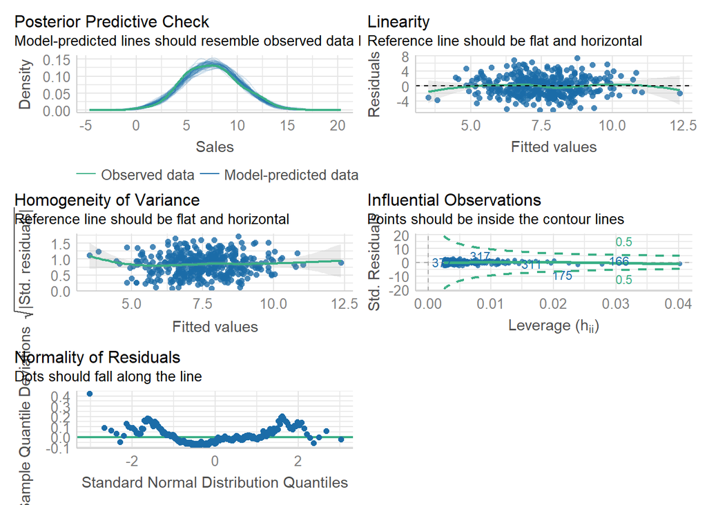

```r
#Check model assumptions
check_model(simple_lm)
```

Most of the model’s assumptions are met except heteroskedasticity (for the graph’s tails); however, we will still proceed with caution. Our model should try to improve its explainability, as the R<sup>2</sup> is very low.

### 1b. Use the lm() function to perform a multi-linear regression with Sales as the response and CompPrice, Income, Advertising, Population, Price, Age, and Education as potential predictors. You may want to try different combinations of the variables to check the model’s significance and the predictor variables’ significance. Are all these predictors significant? If not, which of them are substantial? Why?

Following the initial setup of problem A, I use an lm() function to fit every variable as listed in the instructions. After performing the linear regression, I used the summary() function to summarize the results. Finally, I proceed to check the linear regression through the check_model() function, which quickly outputs a visual check of various model assumptions.

```r
#Q.B Multi Linear Model
multi_lm <- lm(Sales ~ CompPrice + Income +
                 Advertising + Population + Price +
                 Age + Education, Carseats)

#Print out summary
summary(multi_lm)
```

```
Call:
lm(formula = Sales ~ CompPrice + Income + Advertising + Population +
    Price + Age + Education, data = Carseats)

Residuals:
    Min      1Q  Median      3Q     Max
-5.0598 -1.3515 -0.1739  1.1331  4.8304

Coefficients:
              Estimate Std. Error t value Pr(>|t|)
(Intercept)  7.7076934  1.1176260   6.896 2.15e-11 ***
CompPrice    0.0939149  0.0078395  11.980  < 2e-16 ***
Income       0.0128717  0.0034757   3.703 0.000243 ***
Advertising  0.1308637  0.0151219   8.654  < 2e-16 ***
Population  -0.0001239  0.0006877  -0.180 0.857092
Price       -0.0925226  0.0050521 -18.314  < 2e-16 ***
Age         -0.0449743  0.0060083  -7.485 4.75e-13 ***
Education   -0.0399844  0.0371257  -1.077 0.282142
---
Signif. codes:  0 '***' 0.001 '**' 0.01 '*' 0.05 '.' 0.1 ' ' 1

Residual standard error: 1.929 on 392 degrees of freedom
Multiple R-squared:  0.5417,    Adjusted R-squared:  0.5335
F-statistic: 66.18 on 7 and 392 DF,  p-value: < 2.2e-16
```

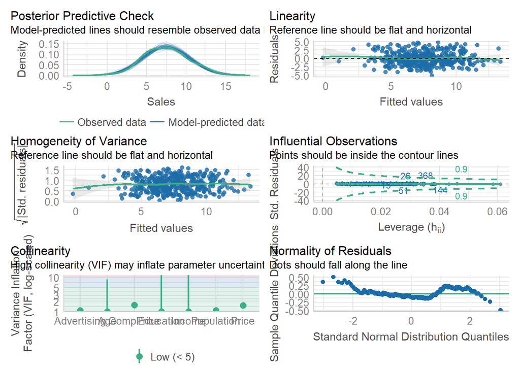

```r
#Check model assumptions
check_model(multi_lm)
```

First, I use the lm() function to perform a multi-linear regression with Sales as the response and CompPrice, Income, Advertising, Population, Price, Age, and Education as potential predictors. For the relationship between Sales and the model, 54.17% of the variation in Sales can be explained through the model. Five statistically significant variables have their expected signs – CompPrice, Income, Advertising, Price, and Age. On the other hand, Education and Population are not statistically significant. Intuitively, this makes sense as income can serve as a proxy for education, as higher levels of human capital will lead to more income. More importantly, education may be less relevant than income regarding buying car seats. As required by law, infants and young children must be in car seats, so education (and higher-level education) is less important than income, as these parents must have income to purchase the car seat. Age can also serve as a proxy for population as it provides more details about the population than just a numerical count. Moreover, parents are most likely to be young; thus, as people age, it is reasonable to assume that people will not need car seats. In essence, the model should only have one of each variable rather than both.

```r
#Multi Linear Model pt 2
multi_lm2 <- lm(Sales ~ CompPrice + Education +
                    Advertising + Price +
                    Age, Carseats)

#Print out summary
summary(multi_lm2)
```

```
Call:
lm(formula = Sales ~ CompPrice + Education + Advertising + Price +
    Age, data = Carseats)

Residuals:
    Min      1Q  Median      3Q     Max
-4.9264 -1.3145 -0.2151  1.2676  5.2882

Coefficients:
             Estimate Std. Error t value Pr(>|t|)
(Intercept)  8.867515   1.037791   8.545 2.86e-16 ***
CompPrice    0.092472   0.007906  11.696  < 2e-16 ***
Education   -0.046600   0.037433  -1.245    0.214
Advertising  0.133214   0.014788   9.008  < 2e-16 ***
Price       -0.092866   0.005124 -18.124  < 2e-16 ***
Age         -0.045207   0.006089  -7.424 7.08e-13 ***
---
Signif. codes:  0 '***' 0.001 '**' 0.01 '*' 0.05 '.' 0.1 ' ' 1

Residual standard error: 1.958 on 394 degrees of freedom
Multiple R-squared:  0.5255,    Adjusted R-squared:  0.5195
F-statistic: 87.27 on 5 and 394 DF,  p-value: < 2.2e-16
```

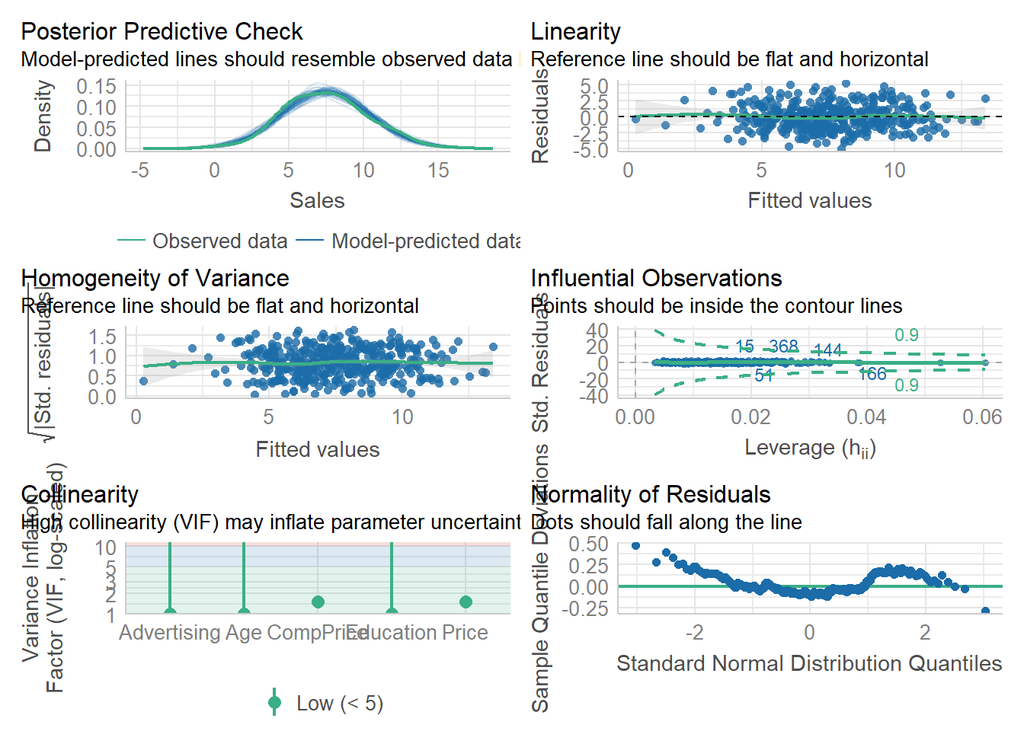

```r
#Check model assumptions
check_model(multi_lm2)
```

Lastly, it is important to mention that there do not appear to be any violations of the assumptions regarding education and population. I used the check_model() function to visualize the assumptions. As mentioned earlier, it is recommended that Education and Population be dropped as they do not provide additional explanations for the variations in Sales.

### **1c. Use the lm() function to perform a multi-linear regression with Sales as the response and Price, Urban, and US as predictor variables. Note that dummy variables are needed for the categorical variables Urban and US. Are all these three significant? Why?**

Following the initial setup from earlier problems, I use a lm() function to fit every variable as listed in the instructions. After performing the linear regression, I use the summary() function to summarize the linear regression results. Finally, I check the linear regression through the check_model() function, which quickly outputs a visual check of various model assumptions. However, it is essential to note that given a qualitative variable such as Urban and US, R generates dummy variables automatically, so I do not need to code them specifically. US is a factor that indicates whether the store is in the US or abroad, whereas Urban is a factor that describes whether the store is in an urban or rural location.

```r
#Q.C LM w/ Dummy Variables
#Print out summary
summary(multi_lm2)
```

```
Call:
lm(formula = Sales ~ CompPrice + Education + Advertising + Price +
    Age, data = Carseats)

Residuals:
    Min      1Q  Median      3Q     Max
-4.9264 -1.3145 -0.2151  1.2676  5.2882

Coefficients:
             Estimate Std. Error t value Pr(>|t|)
(Intercept)  8.867515   1.037791   8.545 2.86e-16 ***
CompPrice    0.092472   0.007906  11.696  < 2e-16 ***
Education   -0.046600   0.037433  -1.245    0.214
Advertising  0.133214   0.014788   9.008  < 2e-16 ***
Price       -0.092866   0.005124 -18.124  < 2e-16 ***
Age         -0.045207   0.006089  -7.424 7.08e-13 ***
---
Signif. codes:  0 '***' 0.001 '**' 0.01 '*' 0.05 '.' 0.1 ' ' 1

Residual standard error: 1.958 on 394 degrees of freedom
Multiple R-squared:  0.5255,    Adjusted R-squared:  0.5195
F-statistic: 87.27 on 5 and 394 DF,  p-value: < 2.2e-16
```

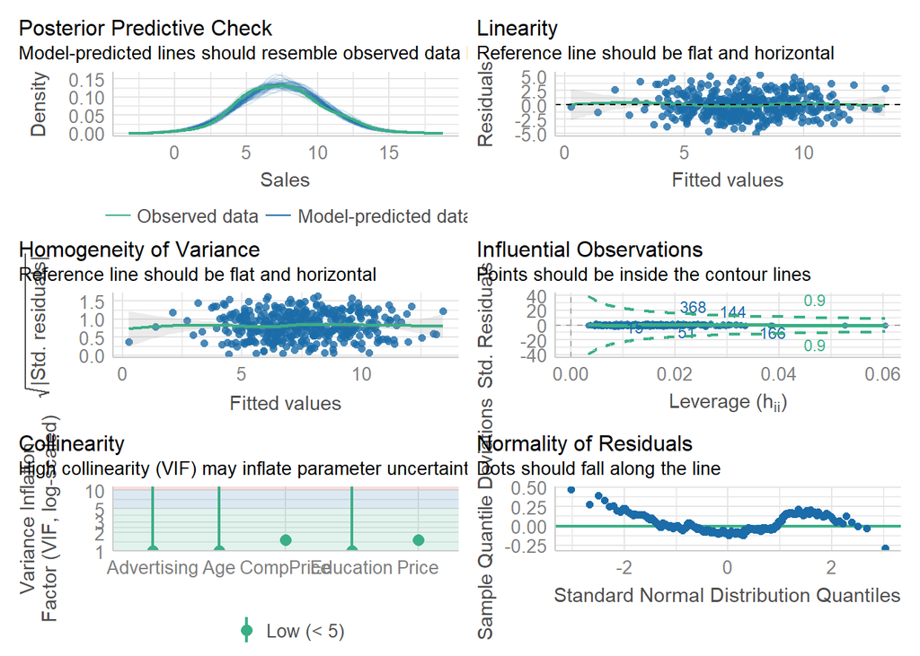

```r
#Check model assumptions
check_model(multi_lm2)
```

```r
#Q.C LM w/ Dummy Variables
dummy_lm <- lm(Sales ~ Price + Urban + US, Carseats)

#Print out summary
summary(dummy_lm)
```

```
Call:
lm(formula = Sales ~ Price + Urban + US, data = Carseats)

Residuals:
    Min      1Q  Median      3Q     Max
-6.9206 -1.6220 -0.0564  1.5786  7.0581

Coefficients:
             Estimate Std. Error t value Pr(>|t|)
(Intercept) 13.043469   0.651012  20.036  < 2e-16 ***
Price       -0.054459   0.005242 -10.389  < 2e-16 ***
UrbanYes    -0.021916   0.271650  -0.081    0.936
USYes        1.200573   0.259042   4.635 4.86e-06 ***
---
Signif. codes:  0 '***' 0.001 '**' 0.01 '*' 0.05 '.' 0.1 ' ' 1

Residual standard error: 2.472 on 396 degrees of freedom
Multiple R-squared:  0.2393,    Adjusted R-squared:  0.2335
F-statistic: 41.52 on 3 and 396 DF,  p-value: < 2.2e-16
```

### 1d. Use the lm() function to perform a multi-linear regression with Sales as the response, CompPrice, Income, Advertising, Population, Price, Age, and Education as potential quantitative predictors, and Urban and US as categorical variables. Note that dummy variables are needed for the categorical variables. You may want to try different combinations of the variables to check the significance of the model and the significance of the predictor variables. Are all these predictors significant? If not, which of them are substantial? Why?

Following the initial setup from earlier problems, I use an lm() function to fit every variable as listed in the instructions. After performing the linear regression, I use the summary() function to summarize the results. Finally, I proceed to check the linear regression through the check_model() function, which quickly outputs a visual check of various model assumptions.

First, I use a lm() function to perform a multi-linear regression with Sales as the response, CompPrice, Income, Advertising, Population, Price, Age, and Education as potential quantitative predictors, and Urban and US as categorical variables. For the relationship between Sales and the model, 54.25% of the variation in Sales can be explained through the model. Five statistically significant variables have their expected signs – CompPrice, Income, Advertising, Price, and Age. On the other hand, Education, Population, USYes, and UrbanYes are not statistically significant. As mentioned in problem B, education and population are not needed in the regression equation; however, neither categorical variable is substantial. This result suggests no expected (or average) difference in Sales between stores in and outside the US and in urban or rural areas. Ultimately, it seems that the store’s location does not help explain variations in Sales. For instance, the company may receive most of its sales from online sources; thus, a physical store is not essential for its sales. Moving forward, it is crucial to investigate the sales to determine its breakdown.

```r
#Q.D Multi LM w/ Dummy Variables
multi_dummy_lm <- lm(Sales ~ CompPrice + Income + Advertising
               + Population + Price + Age
               + Education + Urban + US, Carseats)

#Print out summary
summary(multi_dummy_lm)
```

```
Call:
lm(formula = Sales ~ CompPrice + Income + Advertising + Population +
    Price + Age + Education + Urban + US, data = Carseats)

Residuals:
   Min     1Q Median     3Q    Max
-5.026 -1.341 -0.187  1.141  4.867

Coefficients:
              Estimate Std. Error t value Pr(>|t|)
(Intercept)  7.8243876  1.1298792   6.925 1.81e-11 ***
CompPrice    0.0942545  0.0078637  11.986  < 2e-16 ***
Income       0.0130501  0.0034908   3.738 0.000213 ***
Advertising  0.1369399  0.0210394   6.509 2.33e-10 ***
Population  -0.0002007  0.0007010  -0.286 0.774780
Price       -0.0924395  0.0050621 -18.261  < 2e-16 ***
Age         -0.0447919  0.0060226  -7.437 6.59e-13 ***
Education   -0.0423034  0.0373738  -1.132 0.258371
UrbanYes    -0.1559036  0.2133519  -0.731 0.465380
USYes       -0.1062926  0.2832192  -0.375 0.707640
---
Signif. codes:  0 '***' 0.001 '**' 0.01 '*' 0.05 '.' 0.1 ' ' 1

Residual standard error: 1.932 on 390 degrees of freedom
Multiple R-squared:  0.5425,    Adjusted R-squared:  0.5319
F-statistic: 51.38 on 9 and 390 DF,  p-value: < 2.2e-16
```

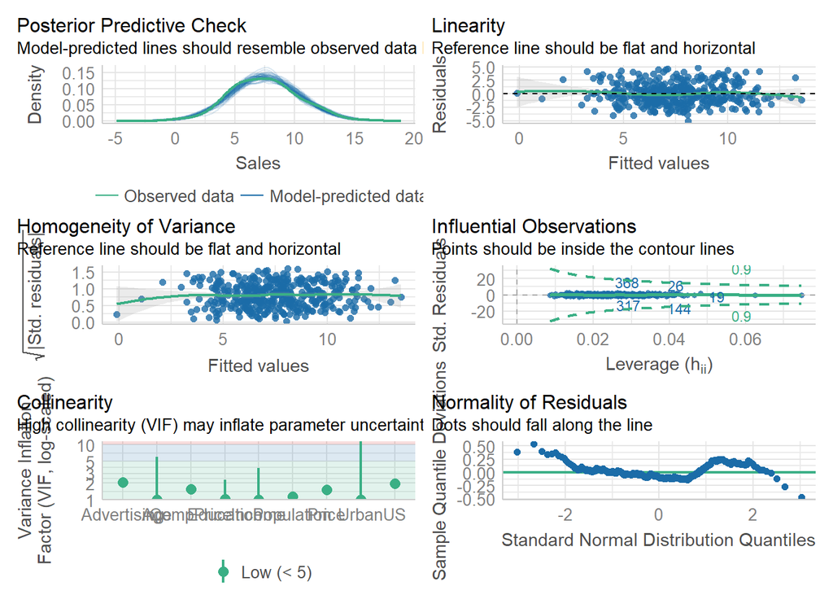

```r
#Check model assumptions
check_model(multi_dummy_lm)
```

Next, I ran a regression that did not include Education and Population but also included an interaction between US and Urban. For the relationship between Sales and this model, 54.16% of the variation in Sales can be explained through the model. Again, five variables are statistically significant and have their expected signs – CompPrice, Income, Advertising, Price, and Age. On the other hand, USYes, UrbanYes, and USYes:UrbanYes are not statistically significant.

```r
#Multi LM w/ Dummy Variables pt2
multi_dummy_lm2 <- lm(Sales ~ CompPrice + Income + Advertising
                      + Price + Age + US + Urban + US:Urban, Carseats)

#Print out summary
summary(multi_dummy_lm2)
```

```
Call:
lm(formula = Sales ~ CompPrice + Income + Advertising + Price +
    Age + US + Urban + US:Urban, data = Carseats)

Residuals:
    Min      1Q  Median      3Q     Max
-4.8345 -1.3646 -0.2118  1.1983  4.7672

Coefficients:
                Estimate Std. Error t value Pr(>|t|)
(Intercept)     7.050078   0.959789   7.345 1.20e-12 ***
CompPrice       0.093784   0.007854  11.941  < 2e-16 ***
Income          0.013124   0.003489   3.761 0.000195 ***
Advertising     0.134357   0.019994   6.720 6.45e-11 ***
Price          -0.092232   0.005069 -18.196  < 2e-16 ***
Age            -0.044632   0.006018  -7.417 7.52e-13 ***
USYes           0.159382   0.413603   0.385 0.700188
UrbanYes        0.061261   0.348673   0.176 0.860623
USYes:UrbanYes -0.329138   0.440392  -0.747 0.455286
---
Signif. codes:  0 '***' 0.001 '**' 0.01 '*' 0.05 '.' 0.1 ' ' 1

Residual standard error: 1.932 on 391 degrees of freedom
Multiple R-squared:  0.5416,    Adjusted R-squared:  0.5322
F-statistic: 57.74 on 8 and 391 DF,  p-value: < 2.2e-16
```

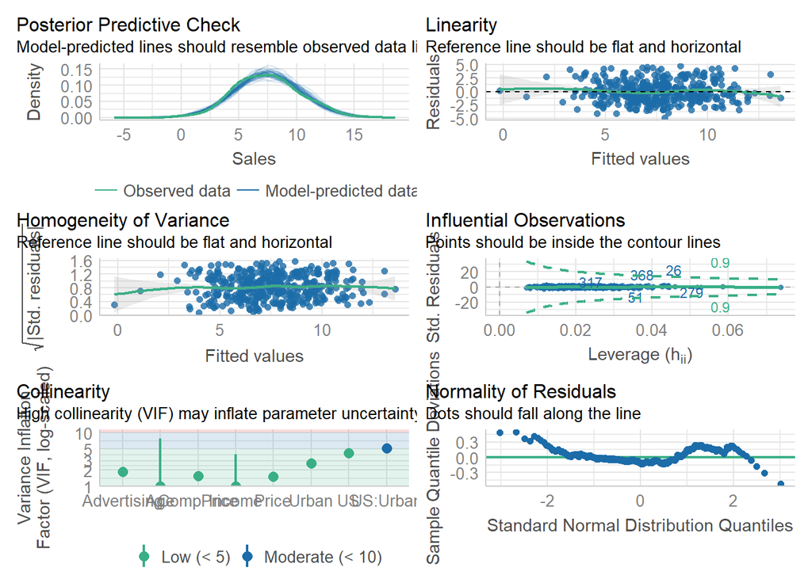

```r
#Check model assumptions
check_model(multi_dummy_lm2)
```

Following this regression, I ran additional regressions that included the different combinations; however, the best model includes CompPrice, Income, Advertising, Price, and Age. This model has a moderately high R<sup>2</sup> and has statistically significant variables with their intended signs. Additionally, this model is simple and makes intuitive sense. As mentioned earlier, any additional combinations or inclusions of other variables do not add additional explanations for the variation in Sales. It seems the most important predictors are CompPrice, Income, Advertising, Price, and Age!

```r
#Multi LM w/ Dummy Variables pt3
multi_dummy_lm3 <- lm(Sales ~ CompPrice + Income + Advertising
                     + Price + Age + US, Carseats)

#Print out summary
summary(multi_dummy_lm3)
```

```
Call:
lm(formula = Sales ~ CompPrice + Income + Advertising + Price +
    Age + US, data = Carseats)

Residuals:
    Min      1Q  Median      3Q     Max
-4.9050 -1.3052 -0.1873  1.1528  4.6943

Coefficients:
             Estimate Std. Error t value Pr(>|t|)
(Intercept)  7.114800   0.945298   7.527 3.59e-13 ***
CompPrice    0.093975   0.007806  12.039  < 2e-16 ***
Income       0.013158   0.003478   3.783 0.000179 ***
Advertising  0.134194   0.019966   6.721 6.36e-11 ***
Price       -0.092522   0.005051 -18.319  < 2e-16 ***
Age         -0.044935   0.006003  -7.486 4.71e-13 ***
USYes       -0.072973   0.277600  -0.263 0.792789
---
Signif. codes:  0 '***' 0.001 '**' 0.01 '*' 0.05 '.' 0.1 ' ' 1

Residual standard error: 1.929 on 393 degrees of freedom
Multiple R-squared:  0.5404,    Adjusted R-squared:  0.5334
F-statistic: 77.01 on 6 and 393 DF,  p-value: < 2.2e-16
```

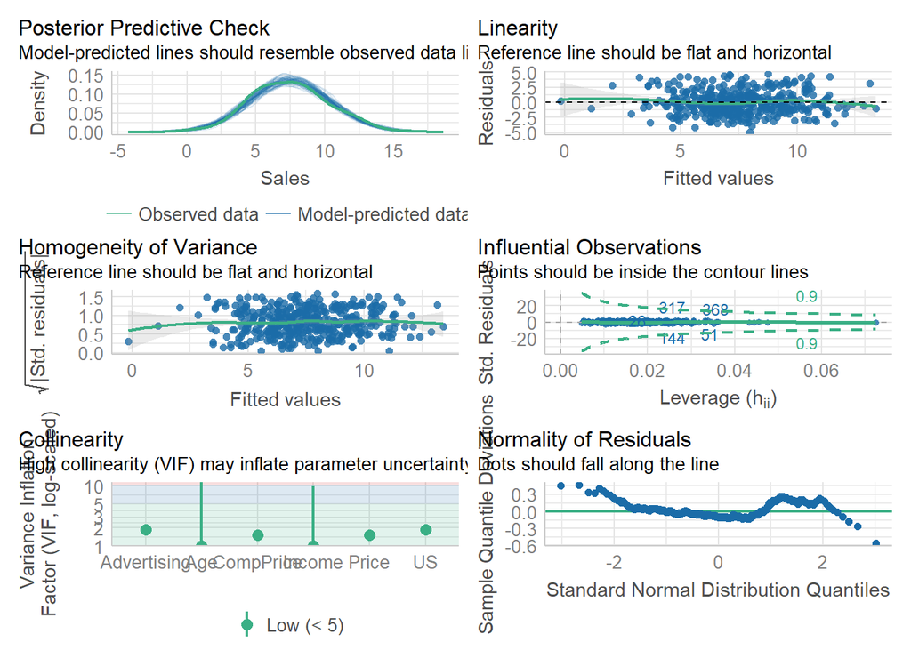

```r
#Check model assumptions
check_model(multi_dummy_lm3)
```

```r
#Multi LM w/ Dummy Variables pt4
multi_dummy_lm4 <- lm(Sales ~ CompPrice + Income
                      + Price + Age + US, Carseats)

#Print out summary
summary(multi_dummy_lm4)
```

```
Call:
lm(formula = Sales ~ CompPrice + Income + Price + Age + US, data = Carseats)

Residuals:
    Min      1Q  Median      3Q     Max
-4.6487 -1.3597 -0.0918  1.2580  5.2602

Coefficients:
             Estimate Std. Error t value Pr(>|t|)
(Intercept)  7.499210   0.995055   7.536 3.35e-13 ***
CompPrice    0.090491   0.008214  11.017  < 2e-16 ***
Income       0.012999   0.003667   3.544 0.000441 ***
Price       -0.091074   0.005321 -17.115  < 2e-16 ***
Age         -0.045628   0.006329  -7.209 2.90e-12 ***
USYes        1.200745   0.213918   5.613 3.75e-08 ***
---
Signif. codes:  0 '***' 0.001 '**' 0.01 '*' 0.05 '.' 0.1 ' ' 1

Residual standard error: 2.034 on 394 degrees of freedom
Multiple R-squared:  0.4875,    Adjusted R-squared:  0.481
F-statistic: 74.97 on 5 and 394 DF,  p-value: < 2.2e-16
```

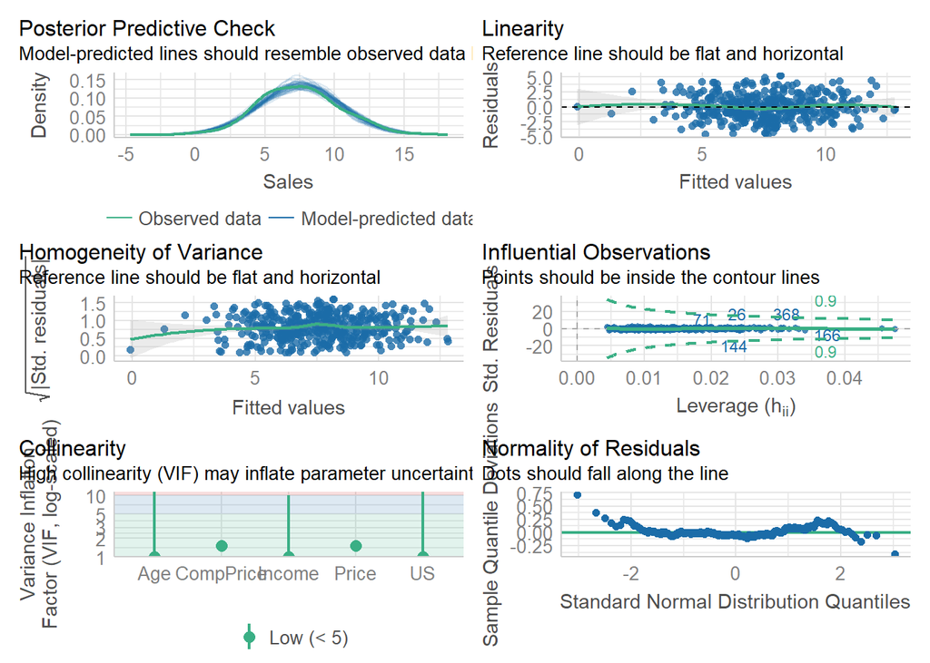

```r
#Check model assumptions
check_model(multi_dummy_lm4)
```

```r
#Multi LM w/ Dummy Variables pt5
multi_dummy_lm5 <- lm(Sales ~ CompPrice + Income + Advertising
                      + Price + Age, Carseats)

#Print out summary
summary(multi_dummy_lm5)
```

```
Call:
lm(formula = Sales ~ CompPrice + Income + Advertising + Price +
    Age, data = Carseats)

Residuals:
    Min      1Q  Median      3Q     Max
-4.9071 -1.3081 -0.1892  1.1495  4.6980

Coefficients:
             Estimate Std. Error t value Pr(>|t|)
(Intercept)  7.109190   0.943940   7.531 3.46e-13 ***
CompPrice    0.093904   0.007792  12.051  < 2e-16 ***
Income       0.013092   0.003465   3.779 0.000182 ***
Advertising  0.130611   0.014572   8.963  < 2e-16 ***
Price       -0.092543   0.005044 -18.347  < 2e-16 ***
Age         -0.044971   0.005994  -7.503 4.20e-13 ***
---
Signif. codes:  0 '***' 0.001 '**' 0.01 '*' 0.05 '.' 0.1 ' ' 1

Residual standard error: 1.927 on 394 degrees of freedom
Multiple R-squared:  0.5403,    Adjusted R-squared:  0.5345
F-statistic: 92.62 on 5 and 394 DF,  p-value: < 2.2e-16
```

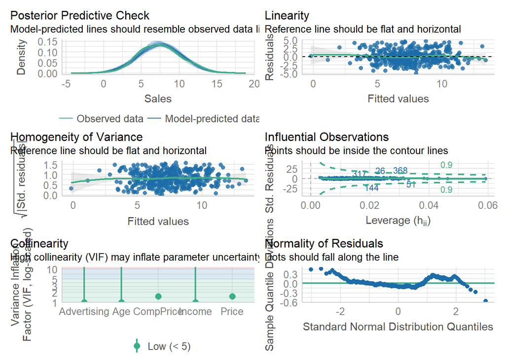

```r
#Check model assumptions
check_model(multi_dummy_lm5)
```

Lastly, it is essential to mention that there do not appear to be any violations of the assumptions. I used the check_model() function, which provides a visualization of the assumptions. As mentioned earlier, it is recommended to drop the Education, Population, US, and urban variables as they do not provide additional explanations for the variations in Sales.